# Classification & Regression Trees

Lauren Forando

Last updated on 2020-08-25

# 1 Modeling

## 1.1 Model fit

Fit model using CART here & save it in `SalePrice_CART_model`.

```r
SalePrice_CART_model2 <- rpart(log(SalePrice+1) ~ BsmtUnfSF + OverallQual + GrLivArea + TotalBsmtSF + YearRemodAdd + GarageArea + factor(Neighborhood) + factor(ExterQual) + factor(HouseStyle) + factor(SaleCondition) + (MSSubClass) + KitchenQual, data = train_validation, control = rpart.control(cp = 0))

y_hat <- predict(SalePrice_CART_model2, type="vector", newdata = test_validation)

test_validation %>%
  mutate(
    SalePrice_hat = exp(y_hat),
    le = log(SalePrice + 1) - log(SalePrice_hat + 1),
    sle = le^2) %>%
  summarize(msle = mean(sle)) %>%
  mutate(rmsle = sqrt(msle))
```

| msle | rmsle |
| --- | --- |
| 0.0362093 | 0.1902873 |

# 2 Choice of complexity parameter `cp`

Write down all the `cp` values you tried and why/how you chose these values.

- First tried `cp = 0` because it was simple, although somewhat arbitrary.
- Then then tried `cp = 0.2` somewhat arbitrarily, and continued with `cp = 0` because the score was better.
- The ultimate Kaggle submission used was`cp = 0`, which was chosen because nothing with a nonzero cp had a lower rmsle than the zero cp.

# 3 Kaggle score

## 3.1 Create submission CSV

```r
sub_predicted <- predict(SalePrice_CART_model2, newdata = test)

submission <- test %>%
  select(Id) %>%
  mutate(SalePrice = exp(sub_predicted)-1)

#submission$SalePrice <- exp(sub_predicted)
write_csv(submission, path = "data/submission.csv")
```

## 3.2 Comparison of multiple regression and CART model Kaggle scores

Compare your Kaggle scores from the multiple regression problem set with your new CART Kaggle score in a cleanly formatted table. Which model had the best score? Make your best guess as to why.

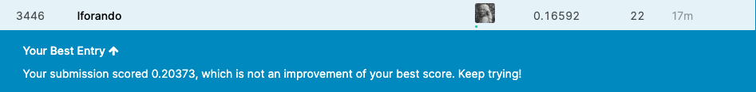

```r
tb <- matrix(c("LaurenF Multiple Regression",0.17887,"CART Model", 0.20373),ncol=2,byrow=TRUE)
colnames(tb) <- c("Name","Kaggle Score")
rownames(tb) <- c(1,2)
tb <- as.table(tb)
tb
```

```
##   Name                        Kaggle Score
## 1 LaurenF Multiple Regression 0.17887
## 2 CART Model                  0.20373
```

The multiple regression model seemed to be better than the CART model. From some searching on the internet it seems that linear regression works better than decision trees on data that can be closely fit to a linear correlation, such as the house pricing data once it was log transformed. CART is said to work better for data where the correlation is much less linear.